# Risk Factor Analysis

## Outcome Variable

**Outcome Variable:** y_rate_haz

## Predictor Variables

**Intervention Variable:** gagebrth

**Adjustment Set:**

unadjusted

## Stratifying Variables

The analysis was stratified on these variable(s):

- diffcat
- studyid
- country

## Data Summary

| diffcat | studyid | country | gagebrth | n_cell | n |
| --- | --- | --- | --- | --- | --- |
| 0-3 months | ki1017093c-NIH-Crypto | BANGLADESH | [273-287) | 239 | 720 |
| 0-3 months | ki1017093c-NIH-Crypto | BANGLADESH | <259 | 148 | 720 |
| 0-3 months | ki1017093c-NIH-Crypto | BANGLADESH | [259-273) | 315 | 720 |
| 0-3 months | ki1017093c-NIH-Crypto | BANGLADESH | >=287 | 18 | 720 |
| 3-6 months | ki1017093c-NIH-Crypto | BANGLADESH | [273-287) | 226 | 695 |
| 3-6 months | ki1017093c-NIH-Crypto | BANGLADESH | <259 | 144 | 695 |
| 3-6 months | ki1017093c-NIH-Crypto | BANGLADESH | [259-273) | 308 | 695 |
| 3-6 months | ki1017093c-NIH-Crypto | BANGLADESH | >=287 | 17 | 695 |
| 6-12 months | ki1017093c-NIH-Crypto | BANGLADESH | [273-287) | 215 | 676 |
| 6-12 months | ki1017093c-NIH-Crypto | BANGLADESH | <259 | 143 | 676 |
| 6-12 months | ki1017093c-NIH-Crypto | BANGLADESH | [259-273) | 301 | 676 |
| 6-12 months | ki1017093c-NIH-Crypto | BANGLADESH | >=287 | 17 | 676 |
| 12-24 months | ki1017093c-NIH-Crypto | BANGLADESH | [273-287) | 147 | 495 |
| 12-24 months | ki1017093c-NIH-Crypto | BANGLADESH | <259 | 106 | 495 |
| 12-24 months | ki1017093c-NIH-Crypto | BANGLADESH | [259-273) | 227 | 495 |
| 12-24 months | ki1017093c-NIH-Crypto | BANGLADESH | >=287 | 15 | 495 |
| 0-3 months | kiGH5241-JiVitA-3 | BANGLADESH | [273-287) | 5937 | 16862 |
| 0-3 months | kiGH5241-JiVitA-3 | BANGLADESH | <259 | 3173 | 16862 |
| 0-3 months | kiGH5241-JiVitA-3 | BANGLADESH | [259-273) | 4445 | 16862 |
| 0-3 months | kiGH5241-JiVitA-3 | BANGLADESH | >=287 | 3307 | 16862 |
| 3-6 months | kiGH5241-JiVitA-3 | BANGLADESH | [273-287) | 3388 | 9519 |
| 3-6 months | kiGH5241-JiVitA-3 | BANGLADESH | <259 | 1681 | 9519 |
| 3-6 months | kiGH5241-JiVitA-3 | BANGLADESH | [259-273) | 2493 | 9519 |
| 3-6 months | kiGH5241-JiVitA-3 | BANGLADESH | >=287 | 1957 | 9519 |
| 6-12 months | kiGH5241-JiVitA-3 | BANGLADESH | [273-287) | 2701 | 7559 |
| 6-12 months | kiGH5241-JiVitA-3 | BANGLADESH | <259 | 1359 | 7559 |
| 6-12 months | kiGH5241-JiVitA-3 | BANGLADESH | [259-273) | 1979 | 7559 |
| 6-12 months | kiGH5241-JiVitA-3 | BANGLADESH | >=287 | 1520 | 7559 |
| 12-24 months | kiGH5241-JiVitA-3 | BANGLADESH | [273-287) | 1278 | 3576 |
| 12-24 months | kiGH5241-JiVitA-3 | BANGLADESH | <259 | 681 | 3576 |

[output cut: 150 more lines]

The following strata were considered:

- diffcat: 0-3 months, studyid: ki1000108-CMC-V-BCS-2002, country: INDIA
- diffcat: 0-3 months, studyid: ki1000108-IRC, country: INDIA
- diffcat: 0-3 months, studyid: ki1000109-EE, country: PAKISTAN
- diffcat: 0-3 months, studyid: ki1000304b-SAS-CompFeed, country: INDIA
- diffcat: 0-3 months, studyid: ki1017093c-NIH-Crypto, country: BANGLADESH
- diffcat: 0-3 months, studyid: ki1101329-Keneba, country: GAMBIA
- diffcat: 0-3 months, studyid: ki1119695-PROBIT, country: BELARUS
- diffcat: 0-3 months, studyid: ki1135781-COHORTS, country: GUATEMALA
- diffcat: 0-3 months, studyid: ki1135781-COHORTS, country: INDIA
- diffcat: 0-3 months, studyid: kiGH5241-JiVitA-3, country: BANGLADESH
- diffcat: 12-24 months, studyid: ki1000108-CMC-V-BCS-2002, country: INDIA
- diffcat: 12-24 months, studyid: ki1000108-IRC, country: INDIA
- diffcat: 12-24 months, studyid: ki1017093c-NIH-Crypto, country: BANGLADESH
- diffcat: 12-24 months, studyid: ki1066203-TanzaniaChild2, country: TANZANIA, UNITED REPUBLIC OF
- diffcat: 12-24 months, studyid: ki1101329-Keneba, country: GAMBIA
- diffcat: 12-24 months, studyid: ki1113344-GMS-Nepal, country: NEPAL
- diffcat: 12-24 months, studyid: ki1119695-PROBIT, country: BELARUS
- diffcat: 12-24 months, studyid: ki1135781-COHORTS, country: GUATEMALA
- diffcat: 12-24 months, studyid: ki1135781-COHORTS, country: INDIA
- diffcat: 12-24 months, studyid: ki1135781-COHORTS, country: PHILIPPINES
- diffcat: 12-24 months, studyid: ki1148112-iLiNS-DYAD-M, country: MALAWI
- diffcat: 12-24 months, studyid: kiGH5241-JiVitA-3, country: BANGLADESH
- diffcat: 3-6 months, studyid: ki1000108-CMC-V-BCS-2002, country: INDIA
- diffcat: 3-6 months, studyid: ki1000108-IRC, country: INDIA
- diffcat: 3-6 months, studyid: ki1000109-EE, country: PAKISTAN
- diffcat: 3-6 months, studyid: ki1000304b-SAS-CompFeed, country: INDIA
- diffcat: 3-6 months, studyid: ki1017093c-NIH-Crypto, country: BANGLADESH
- diffcat: 3-6 months, studyid: ki1066203-TanzaniaChild2, country: TANZANIA, UNITED REPUBLIC OF
- diffcat: 3-6 months, studyid: ki1101329-Keneba, country: GAMBIA
- diffcat: 3-6 months, studyid: ki1113344-GMS-Nepal, country: NEPAL
- diffcat: 3-6 months, studyid: ki1119695-PROBIT, country: BELARUS
- diffcat: 3-6 months, studyid: ki1135781-COHORTS, country: GUATEMALA
- diffcat: 3-6 months, studyid: ki1135781-COHORTS, country: INDIA
- diffcat: 3-6 months, studyid: ki1148112-iLiNS-DYAD-M, country: MALAWI
- diffcat: 3-6 months, studyid: kiGH5241-JiVitA-3, country: BANGLADESH
- diffcat: 6-12 months, studyid: ki1000108-CMC-V-BCS-2002, country: INDIA
- diffcat: 6-12 months, studyid: ki1000108-IRC, country: INDIA
- diffcat: 6-12 months, studyid: ki1000109-EE, country: PAKISTAN
- diffcat: 6-12 months, studyid: ki1000304b-SAS-CompFeed, country: INDIA
- diffcat: 6-12 months, studyid: ki1017093c-NIH-Crypto, country: BANGLADESH
- diffcat: 6-12 months, studyid: ki1066203-TanzaniaChild2, country: TANZANIA, UNITED REPUBLIC OF
- diffcat: 6-12 months, studyid: ki1101329-Keneba, country: GAMBIA
- diffcat: 6-12 months, studyid: ki1113344-GMS-Nepal, country: NEPAL
- diffcat: 6-12 months, studyid: ki1119695-PROBIT, country: BELARUS
- diffcat: 6-12 months, studyid: ki1135781-COHORTS, country: GUATEMALA
- diffcat: 6-12 months, studyid: ki1135781-COHORTS, country: INDIA
- diffcat: 6-12 months, studyid: ki1135781-COHORTS, country: PHILIPPINES
- diffcat: 6-12 months, studyid: ki1148112-iLiNS-DYAD-M, country: MALAWI
- diffcat: 6-12 months, studyid: kiGH5241-JiVitA-3, country: BANGLADESH

### Dropped Strata

Some strata were dropped due to rare outcomes:

- diffcat: 0-3 months, studyid: ki1000304b-SAS-CompFeed, country: INDIA
- diffcat: 3-6 months, studyid: ki1000304b-SAS-CompFeed, country: INDIA
- diffcat: 6-12 months, studyid: ki1000304b-SAS-CompFeed, country: INDIA
- diffcat: 3-6 months, studyid: ki1148112-iLiNS-DYAD-M, country: MALAWI
- diffcat: 3-6 months, studyid: ki1113344-GMS-Nepal, country: NEPAL
- diffcat: 6-12 months, studyid: ki1113344-GMS-Nepal, country: NEPAL
- diffcat: 12-24 months, studyid: ki1113344-GMS-Nepal, country: NEPAL
- diffcat: 0-3 months, studyid: ki1000109-EE, country: PAKISTAN
- diffcat: 3-6 months, studyid: ki1000109-EE, country: PAKISTAN
- diffcat: 6-12 months, studyid: ki1000109-EE, country: PAKISTAN
- diffcat: 12-24 months, studyid: ki1066203-TanzaniaChild2, country: TANZANIA, UNITED REPUBLIC OF

## Methods Detail

We’re interested in the causal parameters $E[Y_a]$ for all values of $a \in \mathcal{A}$. These parameters represent the mean outcome if, possibly contrary to fact, we intervened to set all units to have $A=a$. Under the randomization and positivity assumptions, these are identified by the statistical parameters $\psi_a=E_W[E_{Y|A,W}(Y|A=a,W)]$. In addition, we’re interested in the mean of $Y$, $E[Y]$ under no intervention (the observed mean). We will estimate these parameters by using SuperLearner to fit the relevant likelihood factors – $E_{Y|A,W}(Y|A=a,W)$ and $p(A=a|W)$, and then updating our likelihood fit using a joint TMLE.

For unadjusted analyses ($W=\{\}$), initial likelihoods were estimated using Lrnr_glm to estimate the simple $E(Y|A)$ and Lrnr_mean to estimate $p(A)$. For adjusted analyses, a small library containing Lrnr_glmnet, Lrnr_xgboost, and Lrnr_mean was used.

Having estimated these parameters, we will then use the delta method to estimate relative risks and attributable risks relative to a prespecified baseline level of $A$.

# Results Detail

## Results Plots

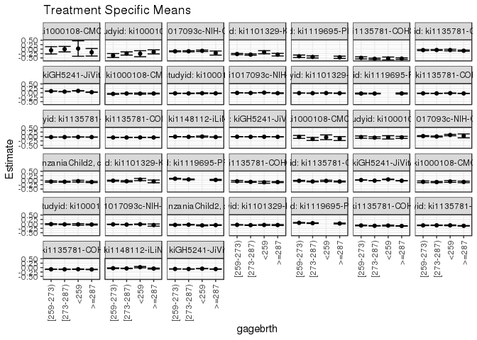

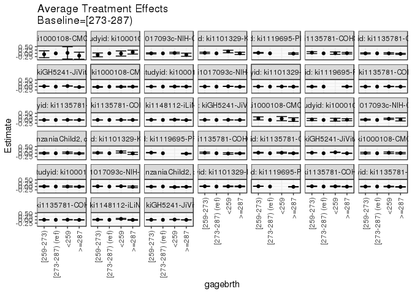

## Results Table

### Parameter: TSM

| diffcat | studyid | country | intervention_level | baseline_level | estimate | ci_lower | ci_upper |
| --- | --- | --- | --- | --- | --- | --- | --- |
| 0-3 months | ki1000108-CMC-V-BCS-2002 | INDIA | [273-287) | NA | -0.0038742 | -0.1596147 | 0.1518663 |
| 0-3 months | ki1000108-CMC-V-BCS-2002 | INDIA | <259 | NA | 0.0296109 | -0.4058706 | 0.4650924 |
| 0-3 months | ki1000108-CMC-V-BCS-2002 | INDIA | [259-273) | NA | -0.0715550 | -0.2785892 | 0.1354793 |
| 0-3 months | ki1000108-CMC-V-BCS-2002 | INDIA | >=287 | NA | -0.1806459 | -0.3934885 | 0.0321967 |
| 0-3 months | ki1000108-IRC | INDIA | [273-287) | NA | -0.2488339 | -0.3380299 | -0.1596379 |
| 0-3 months | ki1000108-IRC | INDIA | <259 | NA | -0.2613060 | -0.4309995 | -0.0916126 |
| 0-3 months | ki1000108-IRC | INDIA | [259-273) | NA | -0.3629557 | -0.4749856 | -0.2509258 |
| 0-3 months | ki1000108-IRC | INDIA | >=287 | NA | -0.1586638 | -0.2736626 | -0.0436650 |
| 0-3 months | ki1017093c-NIH-Crypto | BANGLADESH | [273-287) | NA | -0.1239513 | -0.1567506 | -0.0911520 |
| 0-3 months | ki1017093c-NIH-Crypto | BANGLADESH | <259 | NA | -0.0974495 | -0.1372820 | -0.0576170 |
| 0-3 months | ki1017093c-NIH-Crypto | BANGLADESH | [259-273) | NA | -0.1263702 | -0.1529325 | -0.0998078 |
| 0-3 months | ki1017093c-NIH-Crypto | BANGLADESH | >=287 | NA | -0.2247565 | -0.3397941 | -0.1097189 |
| 0-3 months | ki1101329-Keneba | GAMBIA | [273-287) | NA | -0.3143910 | -0.3524575 | -0.2763244 |
| 0-3 months | ki1101329-Keneba | GAMBIA | <259 | NA | -0.1774205 | -0.2657307 | -0.0891103 |
| 0-3 months | ki1101329-Keneba | GAMBIA | [259-273) | NA | -0.2801620 | -0.3151478 | -0.2451763 |
| 0-3 months | ki1101329-Keneba | GAMBIA | >=287 | NA | -0.3147883 | -0.3896221 | -0.2399544 |
| 0-3 months | ki1119695-PROBIT | BELARUS | [273-287) | NA | -0.4428624 | -0.5028556 | -0.3828692 |
| 0-3 months | ki1119695-PROBIT | BELARUS | [259-273) | NA | -0.4059547 | -0.4770164 | -0.3348931 |
| 0-3 months | ki1119695-PROBIT | BELARUS | >=287 | NA | -0.4625627 | -0.5241238 | -0.4010016 |
| 0-3 months | ki1135781-COHORTS | GUATEMALA | [273-287) | NA | -0.5484818 | -0.5862219 | -0.5107417 |
| 0-3 months | ki1135781-COHORTS | GUATEMALA | <259 | NA | -0.5314157 | -0.6144111 | -0.4484203 |
| 0-3 months | ki1135781-COHORTS | GUATEMALA | [259-273) | NA | -0.4954008 | -0.5557419 | -0.4350597 |
| 0-3 months | ki1135781-COHORTS | GUATEMALA | >=287 | NA | -0.5368255 | -0.5809888 | -0.4926621 |
| 0-3 months | ki1135781-COHORTS | INDIA | [273-287) | NA | -0.0517765 | -0.0782941 | -0.0252589 |
| 0-3 months | ki1135781-COHORTS | INDIA | <259 | NA | -0.0555361 | -0.0999674 | -0.0111048 |
| 0-3 months | ki1135781-COHORTS | INDIA | [259-273) | NA | -0.0571313 | -0.0889524 | -0.0253103 |
| 0-3 months | ki1135781-COHORTS | INDIA | >=287 | NA | -0.0914813 | -0.1225091 | -0.0604534 |
| 0-3 months | kiGH5241-JiVitA-3 | BANGLADESH | [273-287) | NA | 0.0631954 | 0.0556088 | 0.0707819 |
| 0-3 months | kiGH5241-JiVitA-3 | BANGLADESH | <259 | NA | 0.1072031 | 0.0957775 | 0.1186286 |
| 0-3 months | kiGH5241-JiVitA-3 | BANGLADESH | [259-273) | NA | 0.0924562 | 0.0831991 | 0.1017133 |

[output cut: 118 more lines]

### Parameter: E(Y)

| diffcat | studyid | country | intervention_level | baseline_level | estimate | ci_lower | ci_upper |
| --- | --- | --- | --- | --- | --- | --- | --- |
| 0-3 months | ki1000108-CMC-V-BCS-2002 | INDIA | NA | NA | -0.0645622 | -0.1717754 | 0.0426511 |
| 0-3 months | ki1000108-IRC | INDIA | NA | NA | -0.2552533 | -0.3120978 | -0.1984087 |
| 0-3 months | ki1017093c-NIH-Crypto | BANGLADESH | NA | NA | -0.1220821 | -0.1402761 | -0.1038881 |
| 0-3 months | ki1101329-Keneba | GAMBIA | NA | NA | -0.2869811 | -0.3108317 | -0.2631304 |
| 0-3 months | ki1119695-PROBIT | BELARUS | NA | NA | -0.4375900 | -0.4969173 | -0.3782626 |
| 0-3 months | ki1135781-COHORTS | GUATEMALA | NA | NA | -0.5349474 | -0.5599715 | -0.5099233 |
| 0-3 months | ki1135781-COHORTS | INDIA | NA | NA | -0.0630591 | -0.0790628 | -0.0470554 |
| 0-3 months | kiGH5241-JiVitA-3 | BANGLADESH | NA | NA | 0.0732196 | 0.0679849 | 0.0784544 |
| 3-6 months | ki1000108-CMC-V-BCS-2002 | INDIA | NA | NA | -0.0963982 | -0.1464314 | -0.0463649 |
| 3-6 months | ki1000108-IRC | INDIA | NA | NA | -0.0533200 | -0.0841764 | -0.0224636 |
| 3-6 months | ki1017093c-NIH-Crypto | BANGLADESH | NA | NA | 0.0267740 | 0.0099602 | 0.0435879 |
| 3-6 months | ki1066203-TanzaniaChild2 | TANZANIA, UNITED REPUBLIC OF | NA | NA | -0.0857474 | -0.1027530 | -0.0687418 |
| 3-6 months | ki1101329-Keneba | GAMBIA | NA | NA | -0.0387574 | -0.0597399 | -0.0177750 |
| 3-6 months | ki1119695-PROBIT | BELARUS | NA | NA | 0.0470780 | 0.0278572 | 0.0662989 |
| 3-6 months | ki1135781-COHORTS | GUATEMALA | NA | NA | -0.0990042 | -0.1156213 | -0.0823871 |
| 3-6 months | ki1135781-COHORTS | INDIA | NA | NA | -0.0614636 | -0.0743514 | -0.0485759 |
| 3-6 months | kiGH5241-JiVitA-3 | BANGLADESH | NA | NA | -0.0072058 | -0.0128771 | -0.0015345 |
| 6-12 months | ki1000108-CMC-V-BCS-2002 | INDIA | NA | NA | -0.0976775 | -0.1183059 | -0.0770491 |
| 6-12 months | ki1000108-IRC | INDIA | NA | NA | -0.0262272 | -0.0395135 | -0.0129410 |
| 6-12 months | ki1017093c-NIH-Crypto | BANGLADESH | NA | NA | -0.0315658 | -0.0388594 | -0.0242722 |
| 6-12 months | ki1066203-TanzaniaChild2 | TANZANIA, UNITED REPUBLIC OF | NA | NA | -0.0605003 | -0.0699708 | -0.0510298 |
| 6-12 months | ki1101329-Keneba | GAMBIA | NA | NA | -0.0633234 | -0.0720864 | -0.0545604 |
| 6-12 months | ki1119695-PROBIT | BELARUS | NA | NA | 0.0422873 | 0.0257506 | 0.0588239 |
| 6-12 months | ki1135781-COHORTS | GUATEMALA | NA | NA | -0.1074247 | -0.1156062 | -0.0992433 |
| 6-12 months | ki1135781-COHORTS | INDIA | NA | NA | -0.0891165 | -0.0967571 | -0.0814759 |
| 6-12 months | ki1135781-COHORTS | PHILIPPINES | NA | NA | -0.0997523 | -0.1048942 | -0.0946103 |
| 6-12 months | ki1148112-iLiNS-DYAD-M | MALAWI | NA | NA | -0.0435155 | -0.0534192 | -0.0336118 |
| 6-12 months | kiGH5241-JiVitA-3 | BANGLADESH | NA | NA | -0.0767730 | -0.0799829 | -0.0735630 |
| 12-24 months | ki1000108-CMC-V-BCS-2002 | INDIA | NA | NA | -0.0466658 | -0.0572396 | -0.0360921 |
| 12-24 months | ki1000108-IRC | INDIA | NA | NA | -0.0317691 | -0.0390870 | -0.0244512 |
| 12-24 months | ki1017093c-NIH-Crypto | BANGLADESH | NA | NA | -0.0057326 | -0.0097260 | -0.0017391 |
| 12-24 months | ki1101329-Keneba | GAMBIA | NA | NA | -0.0203627 | -0.0246735 | -0.0160519 |
| 12-24 months | ki1119695-PROBIT | BELARUS | NA | NA | -0.0430497 | -0.0603171 | -0.0257823 |
| 12-24 months | ki1135781-COHORTS | GUATEMALA | NA | NA | -0.0331016 | -0.0373272 | -0.0288759 |
| 12-24 months | ki1135781-COHORTS | INDIA | NA | NA | -0.0339532 | -0.0372308 | -0.0306756 |
| 12-24 months | ki1135781-COHORTS | PHILIPPINES | NA | NA | -0.0576585 | -0.0601967 | -0.0551203 |
| 12-24 months | ki1148112-iLiNS-DYAD-M | MALAWI | NA | NA | -0.0204974 | -0.0257171 | -0.0152777 |
| 12-24 months | kiGH5241-JiVitA-3 | BANGLADESH | NA | NA | -0.0193640 | -0.0214128 | -0.0173152 |

### Parameter: ATE

| diffcat | studyid | country | intervention_level | baseline_level | estimate | ci_lower | ci_upper |
| --- | --- | --- | --- | --- | --- | --- | --- |
| 0-3 months | ki1000108-CMC-V-BCS-2002 | INDIA | [273-287) | [273-287) | 0.0000000 | 0.0000000 | 0.0000000 |
| 0-3 months | ki1000108-CMC-V-BCS-2002 | INDIA | <259 | [273-287) | 0.0334851 | -0.4290074 | 0.4959776 |
| 0-3 months | ki1000108-CMC-V-BCS-2002 | INDIA | [259-273) | [273-287) | -0.0676808 | -0.3267528 | 0.1913912 |
| 0-3 months | ki1000108-CMC-V-BCS-2002 | INDIA | >=287 | [273-287) | -0.1767717 | -0.4405085 | 0.0869650 |
| 0-3 months | ki1000108-IRC | INDIA | [273-287) | [273-287) | 0.0000000 | 0.0000000 | 0.0000000 |
| 0-3 months | ki1000108-IRC | INDIA | <259 | [273-287) | -0.0124721 | -0.2041797 | 0.1792354 |
| 0-3 months | ki1000108-IRC | INDIA | [259-273) | [273-287) | -0.1141218 | -0.2573231 | 0.0290795 |
| 0-3 months | ki1000108-IRC | INDIA | >=287 | [273-287) | 0.0901701 | -0.0553656 | 0.2357058 |
| 0-3 months | ki1017093c-NIH-Crypto | BANGLADESH | [273-287) | [273-287) | 0.0000000 | 0.0000000 | 0.0000000 |
| 0-3 months | ki1017093c-NIH-Crypto | BANGLADESH | <259 | [273-287) | 0.0265018 | -0.0250968 | 0.0781004 |
| 0-3 months | ki1017093c-NIH-Crypto | BANGLADESH | [259-273) | [273-287) | -0.0024189 | -0.0446249 | 0.0397871 |
| 0-3 months | ki1017093c-NIH-Crypto | BANGLADESH | >=287 | [273-287) | -0.1008052 | -0.2204272 | 0.0188168 |
| 0-3 months | ki1101329-Keneba | GAMBIA | [273-287) | [273-287) | 0.0000000 | 0.0000000 | 0.0000000 |
| 0-3 months | ki1101329-Keneba | GAMBIA | <259 | [273-287) | 0.1369705 | 0.0408052 | 0.2331357 |
| 0-3 months | ki1101329-Keneba | GAMBIA | [259-273) | [273-287) | 0.0342289 | -0.0174728 | 0.0859306 |
| 0-3 months | ki1101329-Keneba | GAMBIA | >=287 | [273-287) | -0.0003973 | -0.0843567 | 0.0835621 |
| 0-3 months | ki1119695-PROBIT | BELARUS | [273-287) | [273-287) | 0.0000000 | 0.0000000 | 0.0000000 |
| 0-3 months | ki1119695-PROBIT | BELARUS | [259-273) | [273-287) | 0.0369076 | 0.0045342 | 0.0692811 |
| 0-3 months | ki1119695-PROBIT | BELARUS | >=287 | [273-287) | -0.0197003 | -0.0700400 | 0.0306393 |
| 0-3 months | ki1135781-COHORTS | GUATEMALA | [273-287) | [273-287) | 0.0000000 | 0.0000000 | 0.0000000 |
| 0-3 months | ki1135781-COHORTS | GUATEMALA | <259 | [273-287) | 0.0170661 | -0.0741071 | 0.1082393 |
| 0-3 months | ki1135781-COHORTS | GUATEMALA | [259-273) | [273-287) | 0.0530810 | -0.0180904 | 0.1242524 |
| 0-3 months | ki1135781-COHORTS | GUATEMALA | >=287 | [273-287) | 0.0116563 | -0.0464360 | 0.0697486 |
| 0-3 months | ki1135781-COHORTS | INDIA | [273-287) | [273-287) | 0.0000000 | 0.0000000 | 0.0000000 |
| 0-3 months | ki1135781-COHORTS | INDIA | <259 | [273-287) | -0.0037596 | -0.0555024 | 0.0479832 |
| 0-3 months | ki1135781-COHORTS | INDIA | [259-273) | [273-287) | -0.0053548 | -0.0467765 | 0.0360669 |
| 0-3 months | ki1135781-COHORTS | INDIA | >=287 | [273-287) | -0.0397048 | -0.0805203 | 0.0011108 |
| 0-3 months | kiGH5241-JiVitA-3 | BANGLADESH | [273-287) | [273-287) | 0.0000000 | 0.0000000 | 0.0000000 |
| 0-3 months | kiGH5241-JiVitA-3 | BANGLADESH | <259 | [273-287) | 0.0440077 | 0.0306752 | 0.0573402 |
| 0-3 months | kiGH5241-JiVitA-3 | BANGLADESH | [259-273) | [273-287) | 0.0292608 | 0.0182347 | 0.0402870 |

[output cut: 118 more lines]